SECU0005 Crime Mapping | 2026

# Lecture 2: Wrangling data

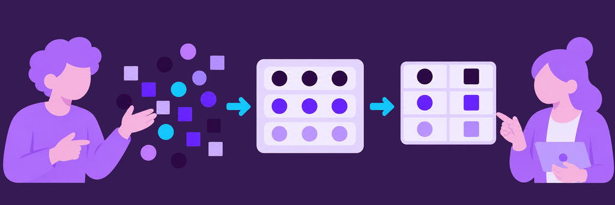

# Last week’s exercise

## Minimal working answer

```r
# Map recorded fatal terrorist attacks in London from 2010 to 2018.

# Load packages
pacman::p_load(here, httr2, sf, sfhotspot, tidyverse)

# Download the original data and keep a local copy
request("https://mpjashby.github.io/crimemappingdata/london_attacks.csv") |>
  req_perform(path = here("data", "raw", "london_attacks.csv")) |>
  # Stop `req_perform()` print a message to the console
  invisible()

# Read dates as text in the consistent YYYY-MM-DD format
attacks <- read_csv(here("data", "raw", "london_attacks.csv"))

# Keep only records within the requested date range, including both ends
attacks_filtered <- filter(attacks, date >= "2010-01-01", date <= "2018-12-31")

# Convert longitude and latitude to a spatial object
attacks_sf <- st_as_sf(
  attacks_filtered,
  coords = c("longitude", "latitude"),
  crs = "EPSG:4326"
)

# Transform to a projected coordinate reference system suitable for London
attacks_sf_trans <- st_transform(attacks_sf, crs = "EPSG:27700")

# Display the map
hotspot_map(
  attacks_sf_trans,
  basemap_type = "cartolight",
  colour = "red2",
  size = 5
)
```

## Minimal working answer

[figure not shown]

## Permanent vs. temporary code

### Permanent code

Code needed to complete a task, e.g. make a map

e.g. `read_csv()` to load a dataset

e.g. `filter()` to filter rows

e.g. `hotspot_map()` to make a map

### Temporary code

Code needed only to *develop* the code needed to complete a task

e.g. `head(attacks)` to find column names

e.g. `check_code()` to check your code

e.g. `excel_sheets()` to find Excel sheet names

## 🚫 No temporary code in R script files

- `col_names()`
- `excel_names()`
- `head()`
- `install.packages()`
- `learncrimemapping::check_code()`
- `names()`
- `show()`
- `str()`

## 😎 Run temporary code in the R console

- `col_names()`
- `excel_names()`
- `head()`
- `install.packages()`
- `learncrimemapping::check_code()`
- `names()`
- `show()`
- `str()`

## Book chapters show where to run each piece of code:

Permanent code to go in a script:

```
chapter_02.R
```

```r
attacks <- read_csv(here("data", "raw", "london_attacks.csv"))
```

Temporary code to go in the R Console:

```
R Console
```

```r
head(attacks)
```

## 🚫 Don’t load packages part-way through scripts

```r
pacman::p_load(tidyverse)

attacks <- read_csv(here("data", "raw", "london_attacks.csv"))

pacman::p_load(sf)

attacks_sf <- st_as_sf(
  attacks,
  coords = c("longitude", "latitude"),
  crs = "EPSG:4326"
)
```

## 🚫 Don’t load packages part-way through scripts

```r
pacman::p_load(tidyverse)

attacks <- read_csv(here("data", "raw", "london_attacks.csv"))

library(sf)

attacks_sf <- st_as_sf(
  attacks,
  coords = c("longitude", "latitude"),
  crs = "EPSG:4326"
)
```

## 😎 Load all the packages at the start of the script

```r
pacman::p_load(sf, tidyverse)

attacks <- read_csv(here("data", "raw", "london_attacks.csv"))

attacks_sf <- st_as_sf(
  attacks,
  coords = c("longitude", "latitude"),
  crs = "EPSG:4326"
)
```

## 🚫 No local file paths

```r
readr::read_csv("/Users/John Smith/crime_mapping/downtown_homicides.csv")
```

```
Error:
! '/Users/John Smith/crime_mapping/downtown_homicides.csv' does not
  exist.
```

```r
readr::read_csv("crime_mapping/Week 1/downtown_homicides.csv")
```

```
Error:
! 'crime_mapping/Week 1/downtown_homicides.csv' does not exist in
  current working directory: '/Users/mattashby/Documents/Crime Mapping
  Book/lectures/2026/02_wrangling_data'.
```

## 😎 Download data inside your script

```r
# Download the original data and keep a local copy
request("https://mpjashby.github.io/crimemappingdata/london_attacks.csv") |>
  req_perform(path = here("data", "raw", "london_attacks.csv"))
```

```
<httr2_response>
GET https://mpjashby.github.io/crimemappingdata/london_attacks.csv
Status: 200 OK
Content-Type: text/csv
Body: On disk '/Users/mattashby/Documents/Crime Mapping Book/lectures/2026/data/raw/london_attacks.csv' (602 bytes)
```

## ⚠️ Copy/paste with care: objects may not exist

```r
# Load the R packages we need to analyse this data
pacman::p_load(sf, sfhotspot, tidyverse)

# Download the data directly from a URL and store it as an object
attacks <- read_csv(here("data", "raw", "london_attacks.csv")) |>
  st_as_sf(coords = c("longitude", "latitude"), crs = "EPSG:4326")

# Plot the map
hotspot_map(homicides_sf_trans)
```

```
Error:
! object 'homicides_sf_trans' not found
```

## ⚠️ Copy/paste with care: different maps need different choices

```r
# Transform the data to a co-ordinate reference system for the state of Georgia
fatal_terrorist_sf_trans <- st_transform(fatal_terrorist_sf, "EPSG:26967")
```

[figure not shown]